# GNN Movie Recommender - Simple & Clear Code

This is the third notebook for the GNN learning with movie dataset.

## A Comprehensive Learning Guide

This notebook is a learning journey from traditional collaborative filtering to Graph Neural Networks (GNNs) for recommendation systems.

## 📦 Setup and Imports

```python
# Install required packages (uncomment if needed)
!pip install torch torch-geometric networkx matplotlib seaborn pandas numpy scikit-learn plotly
```

```python
import torch
import torch.nn as nn
import torch.nn.functional as F
import numpy as np
import pandas as pd
from torch_geometric.nn import GCNConv, SAGEConv, GATConv, LGConv
from torch_geometric.data import Data
from sklearn.model_selection import train_test_split
import matplotlib.pyplot as plt

print("Libraries loaded!")
```

```
Libraries loaded!
```

## Part 1: Load and Prepare Data

```python
# Load MovieLens data
df_ratings = pd.read_csv('/Users/pelinbalci/PycharmProjects/MovieRecommendation/data/ml-latest-small/ratings.csv')
df_movies = pd.read_csv('/Users/pelinbalci/PycharmProjects/MovieRecommendation/data/ml-latest-small/movies.csv')

print(f"Total ratings: {len(df_ratings)}")
print(f"Users: {df_ratings['userId'].nunique()}")
print(f"Movies: {df_ratings['movieId'].nunique()}")
print()
print(df_ratings.head())
```

```
Total ratings: 100836
Users: 610
Movies: 9724

   userId  movieId  rating  timestamp
0       1        1     4.0  964982703
1       1        3     4.0  964981247
2       1        6     4.0  964982224
3       1       47     5.0  964983815
4       1       50     5.0  964982931
```

## Data Preprocessing for GNN

GNNs require:

1. Node indices - Continuous integers starting from 0
2. Edge indices - Pairs of (source, target) nodes
3. Edge attributes - Optional (ratings in our case)

```python
# Create ID mappings (original IDs to 0, 1, 2, ...)
unique_users = sorted(df_ratings['userId'].unique())
unique_movies = sorted(df_ratings['movieId'].unique())

user_to_idx = {user: idx for idx, user in enumerate(unique_users)}
movie_to_idx = {movie: idx for idx, movie in enumerate(unique_movies)}

num_users = len(unique_users)
num_movies = len(unique_movies)
num_nodes = num_users + num_movies

print(f"num_users: {num_users}")
print(f"num_movies: {num_movies}")
print(f"num_nodes (users + movies): {num_nodes}")
```

```
num_users: 610
num_movies: 9724
num_nodes (users + movies): 10334
```

```python
# Apply mappings to create edge indices
df_ratings['user_idx'] = df_ratings['userId'].map(user_to_idx)
df_ratings['movie_idx'] = df_ratings['movieId'].map(movie_to_idx)

# For bipartite graph: movie indices are offset by num_users
df_ratings['movie_idx_global'] = df_ratings['movie_idx'] + num_users

print("Sample of processed data:")
df_ratings[['userId', 'user_idx', 'movieId', 'movie_idx', 'movie_idx_global', 'rating']].head(10)
```

```
Sample of processed data:
```

|  | userId | user_idx | movieId | movie_idx | movie_idx_global | rating |
| --- | --- | --- | --- | --- | --- | --- |
| 0 | 1 | 0 | 1 | 0 | 610 | 4.0 |
| 1 | 1 | 0 | 3 | 2 | 612 | 4.0 |
| 2 | 1 | 0 | 6 | 5 | 615 | 4.0 |
| 3 | 1 | 0 | 47 | 43 | 653 | 5.0 |
| 4 | 1 | 0 | 50 | 46 | 656 | 5.0 |
| 5 | 1 | 0 | 70 | 62 | 672 | 3.0 |
| 6 | 1 | 0 | 101 | 89 | 699 | 5.0 |
| 7 | 1 | 0 | 110 | 97 | 707 | 4.0 |
| 8 | 1 | 0 | 151 | 124 | 734 | 5.0 |
| 9 | 1 | 0 | 157 | 130 | 740 | 5.0 |

```python
# Convert ratings to arrays with new indices
user_indices = np.array([user_to_idx[u] for u in df_ratings['userId']])
movie_indices = np.array([movie_to_idx[m] for m in df_ratings['movieId']])
ratings = df_ratings['rating'].values

print(f"user_indices shape: {user_indices.shape}")
print(f"movie_indices shape: {movie_indices.shape}")
print(f"ratings shape: {ratings.shape}")
print()
print("Sample:")
for i in range(5):
    print(f"  User {user_indices[i]} rated Movie {movie_indices[i]} with {ratings[i]}")
```

```
user_indices shape: (100836,)
movie_indices shape: (100836,)
ratings shape: (100836,)

Sample:
  User 0 rated Movie 0 with 4.0
  User 0 rated Movie 2 with 4.0
  User 0 rated Movie 5 with 4.0
  User 0 rated Movie 43 with 5.0
  User 0 rated Movie 46 with 5.0
```

```python
# Train/Test split
train_idx, test_idx = train_test_split(
    np.arange(len(ratings)),
    test_size=0.2,
    random_state=42
)

train_users = user_indices[train_idx]
train_movies = movie_indices[train_idx]
train_ratings = ratings[train_idx]

test_users = user_indices[test_idx]
test_movies = movie_indices[test_idx]
test_ratings = ratings[test_idx]

print(f"Training samples: {len(train_idx)}")
print(f"Test samples: {len(test_idx)}")
```

```
Training samples: 80668
Test samples: 20168
```

```python
# Convert to tensors (avoids the numpy warning too!)
train_users_t = torch.tensor(train_users, dtype=torch.long)
train_movies_t = torch.tensor(train_movies, dtype=torch.long)

# Movie NODE indices (shifted by num_users)
movie_node_indices = train_movies_t + num_users

# Build edge_index
edge_index = torch.stack([
    torch.cat([train_users_t, movie_node_indices]),    # Source nodes
    torch.cat([movie_node_indices, train_users_t])     # Target nodes
], dim=0)

print(f"edge_index shape: {edge_index.shape}")
print(f"User nodes range: 0 to {num_users - 1}")
print(f"Movie nodes range: {num_users} to {num_users + num_movies - 1}")
print(f"Edge source min/max: {edge_index[0].min().item()} / {edge_index[0].max().item()}")
print(f"Edge target min/max: {edge_index[1].min().item()} / {edge_index[1].max().item()}")
```

```
edge_index shape: torch.Size([2, 161336])
User nodes range: 0 to 609
Movie nodes range: 610 to 10333
Edge source min/max: 0 / 10333
Edge target min/max: 0 / 10333
```

```python
# Convert to tensors
train_users_t = torch.tensor(train_users, dtype=torch.long)
train_movies_t = torch.tensor(train_movies, dtype=torch.long)
train_ratings_t = torch.tensor(train_ratings, dtype=torch.float32)

test_users_t = torch.tensor(test_users, dtype=torch.long)
test_movies_t = torch.tensor(test_movies, dtype=torch.long)
test_ratings_t = torch.tensor(test_ratings, dtype=torch.float32)

print("Data ready!")
```

```
Data ready!
```

## Part 2: Model Definitions

We'll implement and compare several GNN architectures:

1. **GCN (Graph Convolutional Network)** - The classic approach
2. **GraphSAGE** - Sampling and aggregating from neighbors
3. **GAT (Graph Attention Network)** - Attention-based aggregation
4. **LightGCN** - Simplified GCN designed for recommendations

### Model 1: Matrix Factorization (Baseline - No Graph)

```python
class MatrixFactorization(nn.Module):
    """
    Simple Matrix Factorization.
    Does NOT use graph structure - just learns embeddings for users and movies.
    """

    def __init__(self, num_users, num_movies, embedding_dim):
        super().__init__()

        # Store dimensions
        self.num_users = num_users
        self.num_movies = num_movies
        self.embedding_dim = embedding_dim

        # Learnable embeddings
        self.user_embedding = nn.Embedding(num_users, embedding_dim)
        self.movie_embedding = nn.Embedding(num_movies, embedding_dim)

        # Learnable biases
        self.user_bias = nn.Embedding(num_users, 1)
        self.movie_bias = nn.Embedding(num_movies, 1)
        self.global_bias = nn.Parameter(torch.zeros(1))

        # Initialize
        nn.init.xavier_uniform_(self.user_embedding.weight)
        nn.init.xavier_uniform_(self.movie_embedding.weight)
        nn.init.zeros_(self.user_bias.weight)
        nn.init.zeros_(self.movie_bias.weight)

    def forward(self, edge_index, user_idx, movie_idx):
        """
        Predict ratings for given (user, movie) pairs.

        Note: edge_index is NOT used here! It's just for API compatibility.

        Args:
            edge_index: NOT USED (graph structure ignored)
            user_idx: (batch_size,) user indices
            movie_idx: (batch_size,) movie indices

        Returns:
            ratings: (batch_size,) predicted ratings
        """
        # Look up embeddings
        user_emb = self.user_embedding(user_idx)     # (batch, embedding_dim)
        movie_emb = self.movie_embedding(movie_idx)  # (batch, embedding_dim)

        # Dot product
        dot = (user_emb * movie_emb).sum(dim=1)  # (batch,)

        # Add biases
        user_b = self.user_bias(user_idx).squeeze()   # (batch,)
        movie_b = self.movie_bias(movie_idx).squeeze() # (batch,)

        # Final prediction
        rating = dot + user_b + movie_b + self.global_bias

        return rating

print("✅ MatrixFactorization defined")
```

```
✅ MatrixFactorization defined
```

### Model 2: GCN Recommender

```python
class GCNRecommender(nn.Module):
    """
    Graph Convolutional Network for recommendations.

    How it works:
    1. Start with random embeddings for all users and movies
    2. Pass through GCN layers - each node aggregates neighbor info
    3. Split final embeddings into users and movies
    4. Predict rating = dot product of user and movie embeddings
    """

    def __init__(self, num_users, num_movies, embedding_dim, num_layers=2):
        super().__init__()

        # Store dimensions
        self.num_users = num_users
        self.num_movies = num_movies
        self.embedding_dim = embedding_dim
        self.num_layers = num_layers

        # Total nodes = users + movies
        num_nodes = num_users + num_movies

        # Initial embedding for ALL nodes (users + movies together)
        self.embedding = nn.Embedding(num_nodes, embedding_dim)
        nn.init.xavier_uniform_(self.embedding.weight)

        # GCN layers
        self.conv1 = GCNConv(embedding_dim, embedding_dim)
        self.conv2 = GCNConv(embedding_dim, embedding_dim)

    def forward(self, edge_index, user_idx, movie_idx):
        """
        Predict ratings for given (user, movie) pairs.

        Args:
            edge_index: (2, num_edges) graph connectivity
            user_idx: (batch_size,) user indices
            movie_idx: (batch_size,) movie indices

        Returns:
            ratings: (batch_size,) predicted ratings
        """
        # ============================================
        # STEP 1: Get initial embeddings for all nodes
        # ============================================
        x = self.embedding.weight  # (num_nodes, embedding_dim)

        # ============================================
        # STEP 2: Apply GCN layers
        # Each layer: aggregate neighbor embeddings, apply weights, ReLU
        # ============================================

        # Layer 1
        x = self.conv1(x, edge_index)  # (num_nodes, embedding_dim)
        x = F.relu(x)
        x = F.dropout(x, p=0.2, training=self.training)

        # Layer 2
        x = self.conv2(x, edge_index)  # (num_nodes, embedding_dim)
        x = F.relu(x)
        x = F.dropout(x, p=0.2, training=self.training)

        # ============================================
        # STEP 3: Split into user and movie embeddings
        # ============================================
        user_embeddings = x[:self.num_users]       # (num_users, embedding_dim)
        movie_embeddings = x[self.num_users:]      # (num_movies, embedding_dim)

        # ============================================
        # STEP 4: Get embeddings for requested users/movies
        # ============================================
        user_emb = user_embeddings[user_idx]    # (batch_size, embedding_dim)
        movie_emb = movie_embeddings[movie_idx]  # (batch_size, embedding_dim)

        # ============================================
        # STEP 5: Predict rating via dot product
        # ============================================
        rating = (user_emb * movie_emb).sum(dim=1)  # (batch_size,)

        return rating

print("✅ GCNRecommender defined")
```

```
✅ GCNRecommender defined
```

### Model 3: GraphSAGE Recommender

```python
class GraphSAGERecommender(nn.Module):
    """
    GraphSAGE for recommendations.

    Similar to GCN but uses a different aggregation method.
    GraphSAGE: Sample neighbors and aggregate with mean/max/LSTM.
    """

    def __init__(self, num_users, num_movies, embedding_dim, num_layers=2):
        super().__init__()

        # Store dimensions
        self.num_users = num_users
        self.num_movies = num_movies
        self.embedding_dim = embedding_dim
        self.num_layers = num_layers

        # Total nodes = users + movies
        num_nodes = num_users + num_movies

        # Initial embedding for ALL nodes
        self.embedding = nn.Embedding(num_nodes, embedding_dim)
        nn.init.xavier_uniform_(self.embedding.weight)

        # GraphSAGE layers (using mean aggregation)
        self.conv1 = SAGEConv(embedding_dim, embedding_dim)
        self.conv2 = SAGEConv(embedding_dim, embedding_dim)

    def forward(self, edge_index, user_idx, movie_idx):
        """
        Predict ratings for given (user, movie) pairs.
        """
        # STEP 1: Get initial embeddings
        x = self.embedding.weight  # (num_nodes, embedding_dim)

        # STEP 2: Apply GraphSAGE layers
        x = self.conv1(x, edge_index)
        x = F.relu(x)
        x = F.dropout(x, p=0.2, training=self.training)

        x = self.conv2(x, edge_index)
        x = F.relu(x)
        x = F.dropout(x, p=0.2, training=self.training)

        # STEP 3: Split into user and movie embeddings
        user_embeddings = x[:self.num_users]
        movie_embeddings = x[self.num_users:]

        # STEP 4: Get specific user/movie embeddings
        user_emb = user_embeddings[user_idx]
        movie_emb = movie_embeddings[movie_idx]

        # STEP 5: Dot product for rating
        rating = (user_emb * movie_emb).sum(dim=1)

        return rating

print("✅ GraphSAGERecommender defined")
```

```
✅ GraphSAGERecommender defined
```

### Model 4: GAT (Graph Attention Network) Recommender

```python
class GATRecommender(nn.Module):
    """
    Graph Attention Network for recommendations.

    Key difference from GCN:
    - GCN: All neighbors weighted equally (normalized by degree)
    - GAT: Learns ATTENTION weights for each neighbor (some neighbors matter more)
    """

    def __init__(self, num_users, num_movies, embedding_dim, num_layers=2, num_heads=4):
        super().__init__()

        # Store dimensions
        self.num_users = num_users
        self.num_movies = num_movies
        self.embedding_dim = embedding_dim
        self.num_layers = num_layers
        self.num_heads = num_heads

        # Total nodes = users + movies
        num_nodes = num_users + num_movies

        # Initial embedding for ALL nodes
        self.embedding = nn.Embedding(num_nodes, embedding_dim)
        nn.init.xavier_uniform_(self.embedding.weight)

        # GAT layers
        # Note: GAT with multi-head outputs (heads * out_dim), so we adjust dimensions
        head_dim = embedding_dim // num_heads

        self.conv1 = GATConv(embedding_dim, head_dim, heads=num_heads, concat=True)
        self.conv2 = GATConv(embedding_dim, head_dim, heads=num_heads, concat=True)

    def forward(self, edge_index, user_idx, movie_idx):
        """
        Predict ratings for given (user, movie) pairs.
        """
        # STEP 1: Get initial embeddings
        x = self.embedding.weight  # (num_nodes, embedding_dim)

        # STEP 2: Apply GAT layers
        x = self.conv1(x, edge_index)
        x = F.elu(x)  # GAT typically uses ELU, not ReLU
        x = F.dropout(x, p=0.2, training=self.training)

        x = self.conv2(x, edge_index)
        x = F.elu(x)
        x = F.dropout(x, p=0.2, training=self.training)

        # STEP 3: Split into user and movie embeddings
        user_embeddings = x[:self.num_users]
        movie_embeddings = x[self.num_users:]

        # STEP 4: Get specific user/movie embeddings
        user_emb = user_embeddings[user_idx]
        movie_emb = movie_embeddings[movie_idx]

        # STEP 5: Dot product for rating
        rating = (user_emb * movie_emb).sum(dim=1)

        return rating

print("✅ GATRecommender defined")
```

```
✅ GATRecommender defined
```

### Model 5: LightGCN Recommender (State-of-the-Art)

```python
class LightGCNRecommender(nn.Module):
    """
    LightGCN for recommendations.

    Key differences from GCN:
    1. NO weight matrices in convolution layers (only embeddings are learned)
    2. NO activation functions (no ReLU)
    3. AVERAGES embeddings from ALL layers (not just the last one)

    This simpler design often works BETTER for recommendations!
    """

    def __init__(self, num_users, num_movies, embedding_dim, num_layers=3):
        super().__init__()

        # Store dimensions
        self.num_users = num_users
        self.num_movies = num_movies
        self.embedding_dim = embedding_dim
        self.num_layers = num_layers

        # Separate embeddings for users and movies
        # (This is the ONLY learnable part!)
        self.user_embedding = nn.Embedding(num_users, embedding_dim)
        self.movie_embedding = nn.Embedding(num_movies, embedding_dim)

        nn.init.xavier_uniform_(self.user_embedding.weight)
        nn.init.xavier_uniform_(self.movie_embedding.weight)

        # LightGCN convolution layers (NO learnable parameters!)
        self.conv1 = LGConv()  # No parameters!
        self.conv2 = LGConv()  # No parameters!
        self.conv3 = LGConv()  # No parameters!

    def forward(self, edge_index, user_idx, movie_idx):
        """
        Predict ratings for given (user, movie) pairs.
        """
        # ============================================
        # STEP 1: Combine user and movie embeddings
        # ============================================
        x = torch.cat([
            self.user_embedding.weight,   # (num_users, embedding_dim)
            self.movie_embedding.weight   # (num_movies, embedding_dim)
        ], dim=0)  # (num_nodes, embedding_dim)

        # ============================================
        # STEP 2: Store embeddings from each layer
        # ============================================
        all_embeddings = [x]  # Layer 0 = initial embeddings

        # Layer 1 (no ReLU, no dropout!)
        x = self.conv1(x, edge_index)
        all_embeddings.append(x)

        # Layer 2
        x = self.conv2(x, edge_index)
        all_embeddings.append(x)

        # Layer 3
        x = self.conv3(x, edge_index)
        all_embeddings.append(x)

        # ============================================
        # STEP 3: Average ALL layer embeddings
        # This is the key innovation of LightGCN!
        # ============================================
        all_embeddings = torch.stack(all_embeddings, dim=0)  # (4, num_nodes, embedding_dim)
        x = all_embeddings.mean(dim=0)  # (num_nodes, embedding_dim)

        # ============================================
        # STEP 4: Split into user and movie embeddings
        # ============================================
        user_embeddings = x[:self.num_users]
        movie_embeddings = x[self.num_users:]

        # ============================================
        # STEP 5: Get specific user/movie embeddings
        # ============================================
        user_emb = user_embeddings[user_idx]
        movie_emb = movie_embeddings[movie_idx]

        # ============================================
        # STEP 6: Dot product for rating
        # ============================================
        rating = (user_emb * movie_emb).sum(dim=1)

        return rating

print("✅ LightGCNRecommender defined")
```

```
✅ LightGCNRecommender defined
```

```python
class LightGCNRecommenderV2(nn.Module):
    """
    Improved LightGCN with better initialization and optional layer weights.
    """

    def __init__(self, num_users, num_movies, embedding_dim, num_layers=3):
        super().__init__()

        self.num_users = num_users
        self.num_movies = num_movies
        self.embedding_dim = embedding_dim
        self.num_layers = num_layers

        # Embeddings with smaller initialization (important for LightGCN!)
        self.user_embedding = nn.Embedding(num_users, embedding_dim)
        self.movie_embedding = nn.Embedding(num_movies, embedding_dim)

        # Smaller initialization - LightGCN is sensitive to this
        nn.init.normal_(self.user_embedding.weight, std=0.1)
        nn.init.normal_(self.movie_embedding.weight, std=0.1)

        # LightGCN layers
        self.convs = nn.ModuleList([LGConv() for _ in range(num_layers)])

        # Layer combination weights (learnable or fixed)
        # Default: equal weights 1/(num_layers+1)
        self.alpha = 1 / (num_layers + 1)

    def forward(self, edge_index, user_idx, movie_idx):
        # Combine embeddings
        x = torch.cat([self.user_embedding.weight,
                       self.movie_embedding.weight], dim=0)

        # Store all layer embeddings
        all_embeddings = [x]

        # Apply LightGCN layers (no activation, no dropout!)
        for conv in self.convs:
            x = conv(x, edge_index)
            all_embeddings.append(x)

        # Average all layers with equal weight
        x = torch.stack(all_embeddings, dim=0).mean(dim=0)

        # Split
        user_embeddings = x[:self.num_users]
        movie_embeddings = x[self.num_users:]

        # Get batch embeddings
        user_emb = user_embeddings[user_idx]
        movie_emb = movie_embeddings[movie_idx]

        # Predict
        rating = (user_emb * movie_emb).sum(dim=1)

        return rating

print("✅ LightGCNRecommender v2 defined")
```

```
✅ LightGCNRecommender v2 defined
```

## Part 3: Training Function

One simple function to train any model.

```python
def train_model(model, edge_index, train_users, train_movies, train_ratings,
                test_users, test_movies, test_ratings, epochs=100, lr=0.01):
    """
    Train a recommendation model.

    Args:
        model: Any of our recommendation models
        edge_index: Graph structure
        train_*: Training data
        test_*: Test data
        epochs: Number of training epochs
        lr: Learning rate

    Returns:
        history: Dictionary with training metrics
    """

    optimizer = torch.optim.Adam(model.parameters(), lr=lr, weight_decay=1e-5)
    loss_fn = nn.MSELoss()

    history = {'train_loss': [], 'test_rmse': [], 'test_mae': []}

    for epoch in range(epochs):
        # ============================================
        # TRAINING
        # ============================================
        model.train()
        optimizer.zero_grad()

        # Forward pass
        predictions = model(edge_index, train_users, train_movies)

        # Compute loss
        loss = loss_fn(predictions, train_ratings)

        # Backward pass
        loss.backward()
        optimizer.step()

        # ============================================
        # EVALUATION (every 10 epochs)
        # ============================================
        if (epoch + 1) % 10 == 0:
            model.eval()
            with torch.no_grad():
                test_pred = model(edge_index, test_users, test_movies)
                test_pred = test_pred.clamp(0.5, 5.0)  # Clip to valid range

                rmse = torch.sqrt(((test_pred - test_ratings) ** 2).mean()).item()
                mae = (test_pred - test_ratings).abs().mean().item()

            history['train_loss'].append(loss.item())
            history['test_rmse'].append(rmse)
            history['test_mae'].append(mae)

            print(f"Epoch {epoch+1:3d} | Loss: {loss.item():.4f} | RMSE: {rmse:.4f} | MAE: {mae:.4f}")

    return history

print("✅ Training function defined")
```

```
✅ Training function defined
```

## Part 4: Train All Models

```python
EMBEDDING_DIM = 64
EPOCHS = 300
lr=0.01

results = {}
```

```python
# Train Matrix Factorization
print("="*60)
print("TRAINING: Matrix Factorization (baseline)")
print("="*60)

model_mf = MatrixFactorization(num_users, num_movies, EMBEDDING_DIM)
results['MF'] = train_model(
    model_mf, edge_index,
    train_users_t, train_movies_t, train_ratings_t,
    test_users_t, test_movies_t, test_ratings_t,
    epochs=EPOCHS,
    lr=lr
)
```

```
============================================================
TRAINING: Matrix Factorization (baseline)
============================================================
Epoch  10 | Loss: 9.9273 | RMSE: 3.1258 | MAE: 2.9477
Epoch  20 | Loss: 3.1727 | RMSE: 1.8605 | MAE: 1.6347
Epoch  30 | Loss: 1.0296 | RMSE: 1.2421 | MAE: 0.9349
Epoch  40 | Loss: 0.5659 | RMSE: 1.1353 | MAE: 0.8327
Epoch  50 | Loss: 0.5463 | RMSE: 1.2201 | MAE: 0.9515
Epoch  60 | Loss: 0.3690 | RMSE: 1.1121 | MAE: 0.8239
Epoch  70 | Loss: 0.3310 | RMSE: 1.1104 | MAE: 0.8188
Epoch  80 | Loss: 0.2906 | RMSE: 1.1337 | MAE: 0.8490
Epoch  90 | Loss: 0.2533 | RMSE: 1.1223 | MAE: 0.8344
Epoch 100 | Loss: 0.2273 | RMSE: 1.1264 | MAE: 0.8371
Epoch 110 | Loss: 0.2054 | RMSE: 1.1343 | MAE: 0.8460
Epoch 120 | Loss: 0.1851 | RMSE: 1.1355 | MAE: 0.8460
Epoch 130 | Loss: 0.1684 | RMSE: 1.1412 | MAE: 0.8514
Epoch 140 | Loss: 0.1534 | RMSE: 1.1456 | MAE: 0.8555
Epoch 150 | Loss: 0.1400 | RMSE: 1.1496 | MAE: 0.8591
Epoch 160 | Loss: 0.1283 | RMSE: 1.1541 | MAE: 0.8634
Epoch 170 | Loss: 0.1176 | RMSE: 1.1578 | MAE: 0.8670
Epoch 180 | Loss: 0.1081 | RMSE: 1.1616 | MAE: 0.8707
Epoch 190 | Loss: 0.0995 | RMSE: 1.1651 | MAE: 0.8741
Epoch 200 | Loss: 0.0917 | RMSE: 1.1683 | MAE: 0.8773
Epoch 210 | Loss: 0.0846 | RMSE: 1.1713 | MAE: 0.8803
Epoch 220 | Loss: 0.0781 | RMSE: 1.1742 | MAE: 0.8831
Epoch 230 | Loss: 0.0722 | RMSE: 1.1768 | MAE: 0.8858
Epoch 240 | Loss: 0.0668 | RMSE: 1.1793 | MAE: 0.8884
Epoch 250 | Loss: 0.0619 | RMSE: 1.1816 | MAE: 0.8907
Epoch 260 | Loss: 0.0574 | RMSE: 1.1837 | MAE: 0.8929
Epoch 270 | Loss: 0.0533 | RMSE: 1.1857 | MAE: 0.8949
Epoch 280 | Loss: 0.0495 | RMSE: 1.1875 | MAE: 0.8968
Epoch 290 | Loss: 0.0461 | RMSE: 1.1891 | MAE: 0.8986
Epoch 300 | Loss: 0.0429 | RMSE: 1.1907 | MAE: 0.9002
```

```python
# Train GCN
print("\n" + "="*60)
print("TRAINING: GCN Recommender")
print("="*60)

model_gcn = GCNRecommender(num_users, num_movies, EMBEDDING_DIM)
results['GCN'] = train_model(
    model_gcn, edge_index,
    train_users_t, train_movies_t, train_ratings_t,
    test_users_t, test_movies_t, test_ratings_t,
    epochs=EPOCHS,
    lr=lr
)
```

```
============================================================
TRAINING: GCN Recommender
============================================================
Epoch  10 | Loss: 3.8709 | RMSE: 1.6948 | MAE: 1.4033
Epoch  20 | Loss: 1.6440 | RMSE: 1.2106 | MAE: 0.9629
Epoch  30 | Loss: 1.2795 | RMSE: 1.0921 | MAE: 0.8699
Epoch  40 | Loss: 1.1514 | RMSE: 1.0269 | MAE: 0.8160
Epoch  50 | Loss: 1.0643 | RMSE: 0.9786 | MAE: 0.7597
Epoch  60 | Loss: 1.0053 | RMSE: 0.9604 | MAE: 0.7544
Epoch  70 | Loss: 0.9903 | RMSE: 0.9489 | MAE: 0.7443
Epoch  80 | Loss: 0.9624 | RMSE: 0.9453 | MAE: 0.7430
Epoch  90 | Loss: 0.9466 | RMSE: 0.9343 | MAE: 0.7292
Epoch 100 | Loss: 0.9367 | RMSE: 0.9288 | MAE: 0.7236
Epoch 110 | Loss: 0.9295 | RMSE: 0.9284 | MAE: 0.7268
Epoch 120 | Loss: 0.9169 | RMSE: 0.9224 | MAE: 0.7179
Epoch 130 | Loss: 0.8976 | RMSE: 0.9189 | MAE: 0.7068
Epoch 140 | Loss: 0.9077 | RMSE: 0.9147 | MAE: 0.7080
Epoch 150 | Loss: 0.8895 | RMSE: 0.9138 | MAE: 0.7084
Epoch 160 | Loss: 0.8939 | RMSE: 0.9477 | MAE: 0.7571
Epoch 170 | Loss: 0.8880 | RMSE: 0.9193 | MAE: 0.7204
Epoch 180 | Loss: 0.9060 | RMSE: 0.9295 | MAE: 0.7354
Epoch 190 | Loss: 0.8872 | RMSE: 0.9140 | MAE: 0.7135
Epoch 200 | Loss: 0.8806 | RMSE: 0.9171 | MAE: 0.7203
Epoch 210 | Loss: 0.9240 | RMSE: 0.9062 | MAE: 0.7024
Epoch 220 | Loss: 0.9031 | RMSE: 0.9135 | MAE: 0.7140
Epoch 230 | Loss: 0.8733 | RMSE: 0.9140 | MAE: 0.7165
Epoch 240 | Loss: 0.8831 | RMSE: 0.9230 | MAE: 0.7256
Epoch 250 | Loss: 0.8948 | RMSE: 0.9145 | MAE: 0.7187
Epoch 260 | Loss: 0.8834 | RMSE: 0.9052 | MAE: 0.7039
Epoch 270 | Loss: 0.8519 | RMSE: 0.9025 | MAE: 0.6969
Epoch 280 | Loss: 0.8598 | RMSE: 0.9033 | MAE: 0.7001
Epoch 290 | Loss: 0.8645 | RMSE: 0.9000 | MAE: 0.6962
Epoch 300 | Loss: 0.8840 | RMSE: 0.9031 | MAE: 0.6923
```

```python
# Train GraphSAGE
print("\n" + "="*60)
print("TRAINING: GraphSAGE Recommender")
print("="*60)

model_graphsage = GraphSAGERecommender(num_users, num_movies, EMBEDDING_DIM)
results['GraphSAGE'] = train_model(
    model_graphsage, edge_index,
    train_users_t, train_movies_t, train_ratings_t,
    test_users_t, test_movies_t, test_ratings_t,
    epochs=EPOCHS,
    lr=lr
)
```

```
============================================================
TRAINING: GraphSAGE Recommender
============================================================
Epoch  10 | Loss: 3.5479 | RMSE: 1.5847 | MAE: 1.3889
Epoch  20 | Loss: 1.5721 | RMSE: 1.1327 | MAE: 0.9364
Epoch  30 | Loss: 1.2039 | RMSE: 1.0655 | MAE: 0.8783
Epoch  40 | Loss: 1.0307 | RMSE: 0.9717 | MAE: 0.7752
Epoch  50 | Loss: 0.9205 | RMSE: 0.9409 | MAE: 0.7326
Epoch  60 | Loss: 0.8736 | RMSE: 0.9322 | MAE: 0.7255
Epoch  70 | Loss: 0.8812 | RMSE: 0.9322 | MAE: 0.7245
Epoch  80 | Loss: 0.8790 | RMSE: 0.9298 | MAE: 0.7210
Epoch  90 | Loss: 0.8410 | RMSE: 0.9204 | MAE: 0.7034
Epoch 100 | Loss: 0.8628 | RMSE: 0.9211 | MAE: 0.7071
Epoch 110 | Loss: 0.8938 | RMSE: 0.9416 | MAE: 0.7347
Epoch 120 | Loss: 0.8334 | RMSE: 0.9204 | MAE: 0.7021
Epoch 130 | Loss: 0.8359 | RMSE: 0.9247 | MAE: 0.7121
Epoch 140 | Loss: 0.8471 | RMSE: 0.9227 | MAE: 0.7032
Epoch 150 | Loss: 0.8235 | RMSE: 0.9278 | MAE: 0.7165
Epoch 160 | Loss: 0.8320 | RMSE: 0.9278 | MAE: 0.7162
Epoch 170 | Loss: 0.8220 | RMSE: 0.9235 | MAE: 0.7008
Epoch 180 | Loss: 0.8114 | RMSE: 0.9243 | MAE: 0.7061
Epoch 190 | Loss: 0.8059 | RMSE: 0.9345 | MAE: 0.7237
Epoch 200 | Loss: 0.8033 | RMSE: 0.9331 | MAE: 0.7217
Epoch 210 | Loss: 0.8081 | RMSE: 0.9269 | MAE: 0.7123
Epoch 220 | Loss: 0.8092 | RMSE: 0.9243 | MAE: 0.7033
Epoch 230 | Loss: 0.8142 | RMSE: 0.9239 | MAE: 0.7054
Epoch 240 | Loss: 0.7932 | RMSE: 0.9322 | MAE: 0.7174
Epoch 250 | Loss: 0.8355 | RMSE: 0.9337 | MAE: 0.7209
Epoch 260 | Loss: 0.8001 | RMSE: 0.9326 | MAE: 0.7208
Epoch 270 | Loss: 0.8143 | RMSE: 0.9270 | MAE: 0.7127
Epoch 280 | Loss: 0.8084 | RMSE: 0.9281 | MAE: 0.7109
Epoch 290 | Loss: 0.8247 | RMSE: 0.9298 | MAE: 0.7154
Epoch 300 | Loss: 0.7911 | RMSE: 0.9348 | MAE: 0.7219
```

```python
# Train GAT
print("\n" + "="*60)
print("TRAINING: GAT Recommender")
print("="*60)

model_gat = GATRecommender(num_users, num_movies, EMBEDDING_DIM)
results['GAT'] = train_model(
    model_gat, edge_index,
    train_users_t, train_movies_t, train_ratings_t,
    test_users_t, test_movies_t, test_ratings_t,
    epochs=EPOCHS,
    lr=lr
)
```

```
============================================================
TRAINING: GAT Recommender
============================================================
Epoch  10 | Loss: 4.0725 | RMSE: 1.7741 | MAE: 1.5666
Epoch  20 | Loss: 2.0144 | RMSE: 1.4111 | MAE: 1.2191
Epoch  30 | Loss: 1.2586 | RMSE: 1.1727 | MAE: 0.9726
Epoch  40 | Loss: 1.0913 | RMSE: 1.0232 | MAE: 0.8206
Epoch  50 | Loss: 1.0370 | RMSE: 0.9975 | MAE: 0.7891
Epoch  60 | Loss: 1.0132 | RMSE: 0.9888 | MAE: 0.7772
Epoch  70 | Loss: 0.9714 | RMSE: 0.9865 | MAE: 0.7754
Epoch  80 | Loss: 0.9679 | RMSE: 0.9832 | MAE: 0.7720
Epoch  90 | Loss: 0.9490 | RMSE: 0.9770 | MAE: 0.7636
Epoch 100 | Loss: 0.9227 | RMSE: 0.9732 | MAE: 0.7577
Epoch 110 | Loss: 0.9084 | RMSE: 0.9692 | MAE: 0.7514
Epoch 120 | Loss: 0.8988 | RMSE: 0.9680 | MAE: 0.7529
Epoch 130 | Loss: 0.8946 | RMSE: 0.9649 | MAE: 0.7493
Epoch 140 | Loss: 0.8918 | RMSE: 0.9655 | MAE: 0.7540
Epoch 150 | Loss: 0.8897 | RMSE: 0.9651 | MAE: 0.7538
Epoch 160 | Loss: 0.8540 | RMSE: 0.9527 | MAE: 0.7299
Epoch 170 | Loss: 0.8415 | RMSE: 0.9535 | MAE: 0.7272
Epoch 180 | Loss: 0.8575 | RMSE: 0.9477 | MAE: 0.7262
Epoch 190 | Loss: 0.8479 | RMSE: 0.9501 | MAE: 0.7370
Epoch 200 | Loss: 0.8445 | RMSE: 0.9473 | MAE: 0.7288
Epoch 210 | Loss: 0.8402 | RMSE: 0.9425 | MAE: 0.7235
Epoch 220 | Loss: 0.8276 | RMSE: 0.9438 | MAE: 0.7209
Epoch 230 | Loss: 0.8298 | RMSE: 0.9463 | MAE: 0.7291
Epoch 240 | Loss: 0.8325 | RMSE: 0.9453 | MAE: 0.7296
Epoch 250 | Loss: 0.8271 | RMSE: 0.9450 | MAE: 0.7158
Epoch 260 | Loss: 0.8593 | RMSE: 0.9586 | MAE: 0.7516
Epoch 270 | Loss: 0.8368 | RMSE: 0.9665 | MAE: 0.7604
Epoch 280 | Loss: 0.8355 | RMSE: 0.9383 | MAE: 0.7138
Epoch 290 | Loss: 0.8296 | RMSE: 0.9379 | MAE: 0.7257
Epoch 300 | Loss: 0.8239 | RMSE: 0.9524 | MAE: 0.7442
```

```python
# Train LightGCN
print("\n" + "="*60)
print("TRAINING: LightGCN Recommender")
print("="*60)

model_lightgcn = LightGCNRecommender(num_users, num_movies, EMBEDDING_DIM)
results['LightGCN'] = train_model(
    model_lightgcn, edge_index,
    train_users_t, train_movies_t, train_ratings_t,
    test_users_t, test_movies_t, test_ratings_t,
    epochs=EPOCHS,
    lr=lr
)
```

```
============================================================
TRAINING: LightGCN Recommender
============================================================
Epoch  10 | Loss: 7.6854 | RMSE: 2.6052 | MAE: 2.3244
Epoch  20 | Loss: 5.3206 | RMSE: 1.8372 | MAE: 1.5246
Epoch  30 | Loss: 3.9053 | RMSE: 2.0117 | MAE: 1.6939
Epoch  40 | Loss: 3.2842 | RMSE: 1.7575 | MAE: 1.4357
Epoch  50 | Loss: 2.9945 | RMSE: 1.7516 | MAE: 1.4265
Epoch  60 | Loss: 2.7448 | RMSE: 1.6965 | MAE: 1.3707
Epoch  70 | Loss: 2.5082 | RMSE: 1.6550 | MAE: 1.3291
Epoch  80 | Loss: 2.2771 | RMSE: 1.6136 | MAE: 1.2879
Epoch  90 | Loss: 2.0421 | RMSE: 1.5662 | MAE: 1.2402
Epoch 100 | Loss: 1.8209 | RMSE: 1.5202 | MAE: 1.1934
Epoch 110 | Loss: 1.6404 | RMSE: 1.4802 | MAE: 1.1523
Epoch 120 | Loss: 1.5086 | RMSE: 1.4478 | MAE: 1.1188
Epoch 130 | Loss: 1.4073 | RMSE: 1.4228 | MAE: 1.0934
Epoch 140 | Loss: 1.3241 | RMSE: 1.4018 | MAE: 1.0726
Epoch 150 | Loss: 1.2557 | RMSE: 1.3843 | MAE: 1.0553
Epoch 160 | Loss: 1.1979 | RMSE: 1.3691 | MAE: 1.0404
Epoch 170 | Loss: 1.1475 | RMSE: 1.3557 | MAE: 1.0273
Epoch 180 | Loss: 1.1031 | RMSE: 1.3436 | MAE: 1.0155
Epoch 190 | Loss: 1.0635 | RMSE: 1.3324 | MAE: 1.0045
Epoch 200 | Loss: 1.0277 | RMSE: 1.3221 | MAE: 0.9944
Epoch 210 | Loss: 0.9950 | RMSE: 1.3124 | MAE: 0.9849
Epoch 220 | Loss: 0.9650 | RMSE: 1.3033 | MAE: 0.9759
Epoch 230 | Loss: 0.9374 | RMSE: 1.2947 | MAE: 0.9674
Epoch 240 | Loss: 0.9119 | RMSE: 1.2867 | MAE: 0.9595
Epoch 250 | Loss: 0.8882 | RMSE: 1.2792 | MAE: 0.9520
Epoch 260 | Loss: 0.8662 | RMSE: 1.2721 | MAE: 0.9450
Epoch 270 | Loss: 0.8458 | RMSE: 1.2655 | MAE: 0.9384
Epoch 280 | Loss: 0.8268 | RMSE: 1.2593 | MAE: 0.9323
Epoch 290 | Loss: 0.8092 | RMSE: 1.2536 | MAE: 0.9266
Epoch 300 | Loss: 0.7927 | RMSE: 1.2483 | MAE: 0.9213
```

```python
# Train with different learning rate
print("=" * 60)
print("TRAINING: LightGCN V2 (with better initialization)")
print("=" * 60)

model_lightgcn_v2 = LightGCNRecommenderV2(num_users, num_movies, EMBEDDING_DIM)

# Try lower learning rate for LightGCN
results['LightGCN_v2'] = train_model(
    model_lightgcn_v2, edge_index,
    train_users_t, train_movies_t, train_ratings_t,
    test_users_t, test_movies_t, test_ratings_t,
    epochs=EPOCHS,
    lr=0.01  # Lower learning rate!
)
```

```
============================================================
TRAINING: LightGCN V2 (with better initialization)
============================================================
Epoch  10 | Loss: 7.7879 | RMSE: 2.6246 | MAE: 2.3477
Epoch  20 | Loss: 5.3194 | RMSE: 1.8351 | MAE: 1.5216
Epoch  30 | Loss: 3.8578 | RMSE: 2.0075 | MAE: 1.6896
Epoch  40 | Loss: 3.2140 | RMSE: 1.7547 | MAE: 1.4321
Epoch  50 | Loss: 2.8852 | RMSE: 1.7382 | MAE: 1.4120
Epoch  60 | Loss: 2.5765 | RMSE: 1.6792 | MAE: 1.3522
Epoch  70 | Loss: 2.2817 | RMSE: 1.6274 | MAE: 1.2997
Epoch  80 | Loss: 2.0234 | RMSE: 1.5789 | MAE: 1.2500
Epoch  90 | Loss: 1.8108 | RMSE: 1.5302 | MAE: 1.2002
Epoch 100 | Loss: 1.6486 | RMSE: 1.4920 | MAE: 1.1609
Epoch 110 | Loss: 1.5232 | RMSE: 1.4616 | MAE: 1.1299
Epoch 120 | Loss: 1.4227 | RMSE: 1.4366 | MAE: 1.1050
Epoch 130 | Loss: 1.3397 | RMSE: 1.4160 | MAE: 1.0844
Epoch 140 | Loss: 1.2692 | RMSE: 1.3979 | MAE: 1.0667
Epoch 150 | Loss: 1.2082 | RMSE: 1.3821 | MAE: 1.0510
Epoch 160 | Loss: 1.1543 | RMSE: 1.3677 | MAE: 1.0367
Epoch 170 | Loss: 1.1062 | RMSE: 1.3545 | MAE: 1.0237
Epoch 180 | Loss: 1.0626 | RMSE: 1.3423 | MAE: 1.0116
Epoch 190 | Loss: 1.0228 | RMSE: 1.3309 | MAE: 1.0003
Epoch 200 | Loss: 0.9863 | RMSE: 1.3201 | MAE: 0.9898
Epoch 210 | Loss: 0.9527 | RMSE: 1.3101 | MAE: 0.9798
Epoch 220 | Loss: 0.9217 | RMSE: 1.3006 | MAE: 0.9703
Epoch 230 | Loss: 0.8930 | RMSE: 1.2918 | MAE: 0.9615
Epoch 240 | Loss: 0.8666 | RMSE: 1.2835 | MAE: 0.9532
Epoch 250 | Loss: 0.8422 | RMSE: 1.2759 | MAE: 0.9456
Epoch 260 | Loss: 0.8197 | RMSE: 1.2689 | MAE: 0.9386
Epoch 270 | Loss: 0.7989 | RMSE: 1.2625 | MAE: 0.9323
Epoch 280 | Loss: 0.7797 | RMSE: 1.2566 | MAE: 0.9264
Epoch 290 | Loss: 0.7620 | RMSE: 1.2513 | MAE: 0.9211
Epoch 300 | Loss: 0.7455 | RMSE: 1.2464 | MAE: 0.9163
```

## Part 5: Compare Results

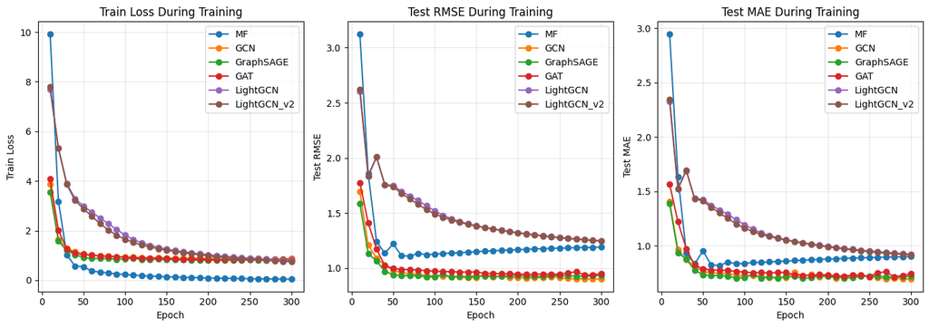

```python
# Plot training curves
fig, axes = plt.subplots(1, 3, figsize=(14, 5))

# LOSS
ax = axes[0]
for name, history in results.items():
    epochs = range(10, EPOCHS + 1, 10)
    ax.plot(epochs, history['train_loss'], marker='o', label=name)
ax.set_xlabel('Epoch')
ax.set_ylabel('Train Loss')
ax.set_title('Train Loss During Training')
ax.legend()
ax.grid(True, alpha=0.3)



# RMSE
ax = axes[1]
for name, history in results.items():
    epochs = range(10, EPOCHS + 1, 10)
    ax.plot(epochs, history['test_rmse'], marker='o', label=name)
ax.set_xlabel('Epoch')
ax.set_ylabel('Test RMSE')
ax.set_title('Test RMSE During Training')
ax.legend()
ax.grid(True, alpha=0.3)

# MAE
ax = axes[2]
for name, history in results.items():
    epochs = range(10, EPOCHS + 1, 10)
    ax.plot(epochs, history['test_mae'], marker='o', label=name)
ax.set_xlabel('Epoch')
ax.set_ylabel('Test MAE')
ax.set_title('Test MAE During Training')
ax.legend()
ax.grid(True, alpha=0.3)

plt.tight_layout()
plt.show()
```

```python
# Final comparison table
final_results = []
for name, history in results.items():
    final_results.append({
        'Model': name,
        'Final RMSE': history['test_rmse'][-1],
        'Final MAE': history['test_mae'][-1],
        'Best RMSE': min(history['test_rmse']),
        'Best MAE': min(history['test_mae'])
    })

comparison_df = pd.DataFrame(final_results)
comparison_df = comparison_df.sort_values('Best RMSE')
print("\n" + "="*60)
print("FINAL MODEL COMPARISON")
print("="*60)
print(comparison_df.to_string(index=False))
```

```
============================================================
FINAL MODEL COMPARISON
============================================================
      Model  Final RMSE  Final MAE  Best RMSE  Best MAE
        GCN    0.903101   0.692320   0.900006  0.692320
  GraphSAGE    0.934825   0.721902   0.920378  0.700808
        GAT    0.952401   0.744175   0.937935  0.713765
         MF    1.190663   0.900227   1.110420  0.818766
LightGCN_v2    1.246386   0.916313   1.246386  0.916313
   LightGCN    1.248263   0.921274   1.248263  0.921274
```

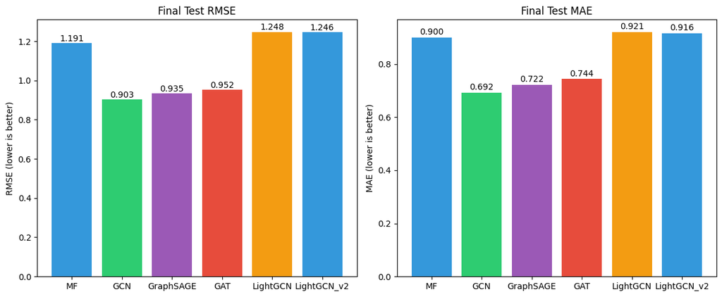

```python
# Bar chart comparison
fig, axes = plt.subplots(1, 2, figsize=(12, 5))

models = list(results.keys())
final_rmse = [results[m]['test_rmse'][-1] for m in models]
final_mae = [results[m]['test_mae'][-1] for m in models]

colors = ['#3498db', '#2ecc71', '#9b59b6', '#e74c3c', '#f39c12']

# RMSE bar chart
ax = axes[0]
bars = ax.bar(models, final_rmse, color=colors)
ax.set_ylabel('RMSE (lower is better)')
ax.set_title('Final Test RMSE')
for bar, val in zip(bars, final_rmse):
    ax.text(bar.get_x() + bar.get_width()/2, bar.get_height() + 0.01,
            f'{val:.3f}', ha='center', fontsize=10)

# MAE bar chart
ax = axes[1]
bars = ax.bar(models, final_mae, color=colors)
ax.set_ylabel('MAE (lower is better)')
ax.set_title('Final Test MAE')
for bar, val in zip(bars, final_mae):
    ax.text(bar.get_x() + bar.get_width()/2, bar.get_height() + 0.01,
            f'{val:.3f}', ha='center', fontsize=10)

plt.tight_layout()
plt.show()
```

## 🔍 Part 6: Embedding Visualization

Let's visualize what the models have learned!

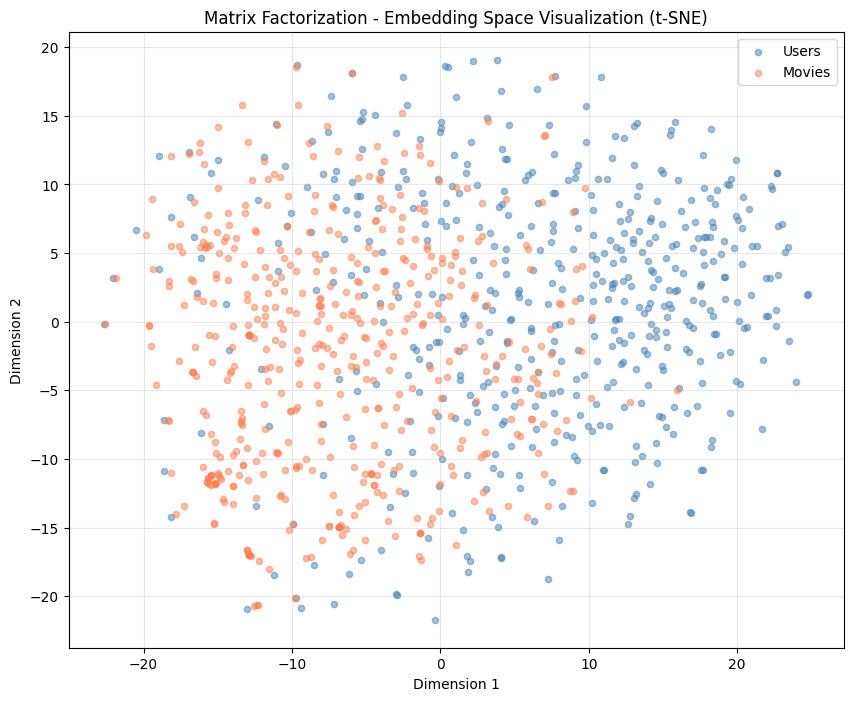

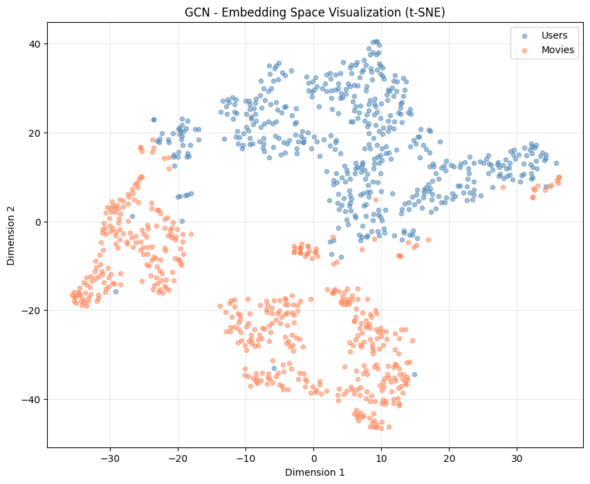

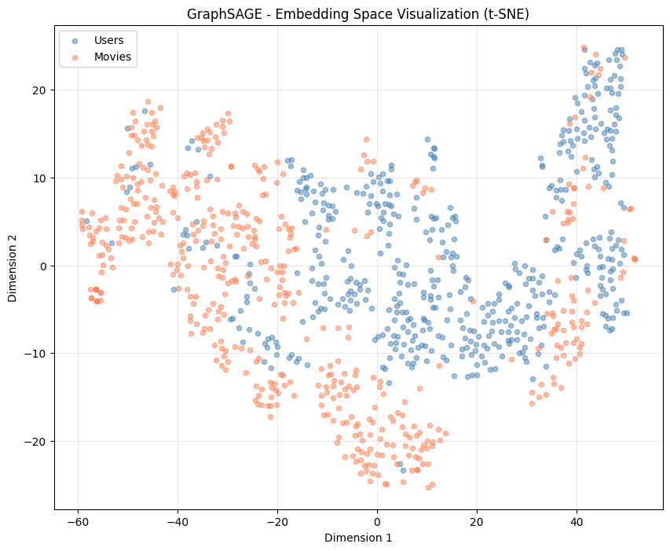

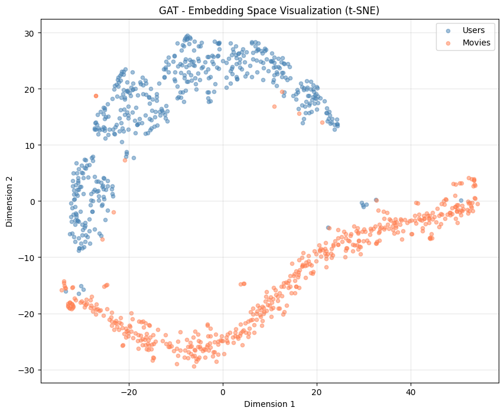

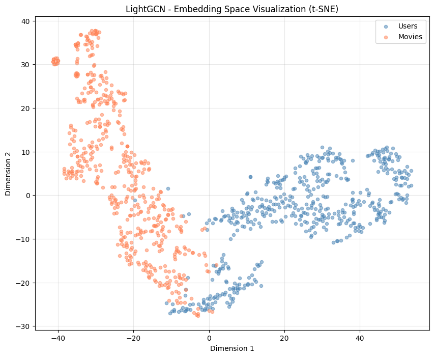

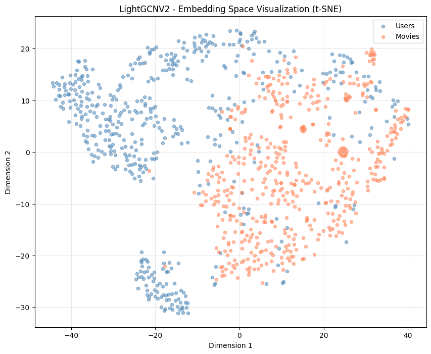

```python
from sklearn.manifold import TSNE

def visualize_embeddings(model, edge_index, num_users, num_movies, model_name, n_samples=500):
    """
    Visualize learned embeddings using t-SNE.

    Args:
        model: Trained model (any of our recommenders)
        edge_index: Graph connectivity tensor
        num_users: Number of users
        num_movies: Number of movies
        model_name: String name for the plot title
        n_samples: Number of samples to visualize (for speed)
    """
    model.eval()

    with torch.no_grad():
        # ============================================
        # Get embeddings based on model type
        # ============================================
        if hasattr(model, 'user_embedding') and hasattr(model, 'movie_embedding'):
            # LightGCN or MatrixFactorization style (separate embeddings)

            if hasattr(model, 'conv1'):  # It's LightGCN - need to apply convolutions
                # Combine embeddings
                x = torch.cat([model.user_embedding.weight,
                              model.movie_embedding.weight], dim=0)

                # Apply LightGCN layers
                all_embeddings = [x]
                x = model.conv1(x, edge_index)
                all_embeddings.append(x)
                x = model.conv2(x, edge_index)
                all_embeddings.append(x)
                x = model.conv3(x, edge_index)
                all_embeddings.append(x)

                # Average all layers
                x = torch.stack(all_embeddings, dim=0).mean(dim=0)

                user_emb = x[:num_users]
                movie_emb = x[num_users:]
            else:
                # MatrixFactorization - just use raw embeddings
                user_emb = model.user_embedding.weight
                movie_emb = model.movie_embedding.weight
        else:
            # GCN, GraphSAGE, GAT style (combined embedding)
            x = model.embedding.weight

            # Apply convolution layers
            x = model.conv1(x, edge_index)
            x = F.relu(x)
            x = model.conv2(x, edge_index)
            x = F.relu(x)

            user_emb = x[:num_users]
            movie_emb = x[num_users:]

    # ============================================
    # Sample for visualization (t-SNE is slow on large data)
    # ============================================
    user_sample = user_emb[:min(n_samples, num_users)].detach().cpu().numpy()
    movie_sample = movie_emb[:min(n_samples, num_movies)].detach().cpu().numpy()

    # Combine
    all_emb = np.vstack([user_sample, movie_sample])
    labels = ['User'] * len(user_sample) + ['Movie'] * len(movie_sample)

    # ============================================
    # t-SNE dimensionality reduction
    # ============================================
    tsne = TSNE(n_components=2, random_state=42, perplexity=30)
    emb_2d = tsne.fit_transform(all_emb)

    # ============================================
    # Plot
    # ============================================
    plt.figure(figsize=(10, 8))

    user_mask = np.array(labels) == 'User'
    movie_mask = np.array(labels) == 'Movie'

    plt.scatter(emb_2d[user_mask, 0], emb_2d[user_mask, 1],
               c='steelblue', alpha=0.5, label='Users', s=20)
    plt.scatter(emb_2d[movie_mask, 0], emb_2d[movie_mask, 1],
               c='coral', alpha=0.5, label='Movies', s=20)

    plt.legend()
    plt.title(f'{model_name} - Embedding Space Visualization (t-SNE)')
    plt.xlabel('Dimension 1')
    plt.ylabel('Dimension 2')
    plt.grid(True, alpha=0.3)
    plt.show()


# ============================================
# Usage:
# ============================================
visualize_embeddings(model_mf, edge_index, num_users, num_movies, 'Matrix Factorization')
visualize_embeddings(model_gcn, edge_index, num_users, num_movies, 'GCN')
visualize_embeddings(model_graphsage, edge_index, num_users, num_movies, 'GraphSAGE')
visualize_embeddings(model_gat, edge_index, num_users, num_movies, 'GAT')
visualize_embeddings(model_lightgcn, edge_index, num_users, num_movies, 'LightGCN')
visualize_embeddings(model_lightgcn_v2, edge_index, num_users, num_movies, 'LightGCNV2')
```

## How to Interpret these results?

GCN, GAT, LightGCN show clear separation between users (blue) and movies (orange). This is actually BAD for recommendations because:

If users are in one region and movies in another:

```
       User space          Movie space
       ┌─────────┐         ┌─────────┐
       │ 👤 👤 👤 │         │ 🎬 🎬 🎬 │
       │ 👤 👤 👤 │   GAP   │ 🎬 🎬 🎬 │
       │ 👤 👤 👤 │         │ 🎬 🎬 🎬 │
       └─────────┘         └─────────┘


→ Dot product between user & movie will be similar for ALL pairs!
→ Model can't distinguish which user likes which movie!
```

GraphSAGE shows better mixing:

```
   Mixed embedding space
   ┌─────────────────────┐
   │ 👤 🎬 👤 🎬 🎬 👤    │
   │ 🎬 👤 🎬 👤 👤 🎬    │  ← Users near their favorite movies
   │ 👤 🎬 🎬 👤 🎬 👤    │
   └─────────────────────┘

   → User close to movies they like
   → User far from movies they don't like
   → Better predictions!
```

📈 Why GCN Has Best RMSE But Separated Embeddings?

This seems contradictory! Here's why:

- t-SNE is just visualization - it compresses 64 dimensions to 2 dimensions and can distort relationships
- Dot product works differently - even if users and movies look separated in 2D, in 64D they might have meaningful dot products
- GCN might be learning different patterns - the separation in t-SNE might not reflect the actual prediction quality

```python
# Check if embedding quality matches intuition
def analyze_embeddings(model, edge_index, num_users, num_movies, df_ratings, df_movies, unique_movies):
    """Analyze if embeddings make sense."""

    model.eval()
    with torch.no_grad():
        # Get embeddings (adjust based on model type)
        if hasattr(model, 'embedding'):
            x = model.embedding.weight
            x = model.conv1(x, edge_index)
            x = F.relu(x)
            x = model.conv2(x, edge_index)
            x = F.relu(x)
            user_emb = x[:num_users].numpy()
            movie_emb = x[num_users:].numpy()
        else:
            # LightGCN style
            x = torch.cat([model.user_embedding.weight, model.movie_embedding.weight], dim=0)
            all_emb = [x]
            for conv in [model.conv1, model.conv2, model.conv3]:
                x = conv(x, edge_index)
                all_emb.append(x)
            x = torch.stack(all_emb, dim=0).mean(dim=0)
            user_emb = x[:num_users].numpy()
            movie_emb = x[num_users:].numpy()

    # Test 1: Are similar movies close?
    print("=" * 60)
    print("TEST 1: Are similar movies close in embedding space?")
    print("=" * 60)

    # Pick a popular movie
    test_movie_idx = 0  # First movie
    test_movie_id = unique_movies[test_movie_idx]
    test_movie_title = df_movies[df_movies['movieId'] == test_movie_id]['title'].values[0]

    # Find similar movies by embedding
    test_emb = movie_emb[test_movie_idx]
    similarities = movie_emb @ test_emb
    top_similar = np.argsort(similarities)[::-1][1:6]  # Top 5 (excluding itself)

    print(f"\nMovies most similar to: '{test_movie_title}'")
    for idx in top_similar:
        movie_id = unique_movies[idx]
        title = df_movies[df_movies['movieId'] == movie_id]['title'].values[0]
        print(f"  - {title[:50]} (similarity: {similarities[idx]:.3f})")

    # Test 2: Is a user close to movies they rated highly?
    print("\n" + "=" * 60)
    print("TEST 2: Is a user close to movies they rated highly?")
    print("=" * 60)

    test_user_idx = 0
    user_vec = user_emb[test_user_idx]

    # Movies this user rated highly
    user_ratings = df_ratings[df_ratings['userId'] == 1].sort_values('rating', ascending=False)
    high_rated = user_ratings[user_ratings['rating'] >= 4.5].head(5)

    print(f"\nUser 1's highly rated movies and their embedding similarity:")
    for _, row in high_rated.iterrows():
        movie_id = row['movieId']
        if movie_id in movie_to_idx:
            movie_idx = movie_to_idx[movie_id]
            movie_vec = movie_emb[movie_idx]
            sim = np.dot(user_vec, movie_vec)
            title = df_movies[df_movies['movieId'] == movie_id]['title'].values[0]
            print(f"  {title[:40]:<40} rating={row['rating']}, sim={sim:.3f}")

    # Test 3: Is a user far from movies they rated poorly?
    low_rated = user_ratings[user_ratings['rating'] <= 2.0].head(5)

    print(f"\nUser 1's low rated movies and their embedding similarity:")
    if len(low_rated) > 0:
        for _, row in low_rated.iterrows():
            movie_id = row['movieId']
            if movie_id in movie_to_idx:
                movie_idx = movie_to_idx[movie_id]
                movie_vec = movie_emb[movie_idx]
                sim = np.dot(user_vec, movie_vec)
                title = df_movies[df_movies['movieId'] == movie_id]['title'].values[0]
                print(f"  {title[:40]:<40} rating={row['rating']}, sim={sim:.3f}")
    else:
        print("  (User 1 has no low ratings)")


print("GCN:")
print("=" * 60)
# Run for best model (GCN)
analyze_embeddings(model_gcn, edge_index, num_users, num_movies, df_ratings, df_movies, unique_movies)

print("GRAPHSAGE:")
print("=" * 60)
# Run for best model (GraphSage)
analyze_embeddings(model_graphsage, edge_index, num_users, num_movies, df_ratings, df_movies, unique_movies)


print("Light:")
print("=" * 60)
# Run for best model (model_lightgcn)
analyze_embeddings(model_lightgcn, edge_index, num_users, num_movies, df_ratings, df_movies, unique_movies)
```

```
GCN:
============================================================
============================================================
TEST 1: Are similar movies close in embedding space?
============================================================

Movies most similar to: 'Toy Story (1995)'
  - A Cosmic Christmas (1977) (similarity: 6.122)
  - Jeff Ross Roasts the Border (2017) (similarity: 5.992)
  - Perfect Plan, A (Plan parfait, Un) (2012) (similarity: 5.784)
  - Dr. Goldfoot and the Bikini Machine (1965) (similarity: 5.757)
  - Bossa Nova (2000) (similarity: 5.718)

============================================================
TEST 2: Is a user close to movies they rated highly?
============================================================

User 1's highly rated movies and their embedding similarity:
  M*A*S*H (a.k.a. MASH) (1970)             rating=5.0, sim=4.792
  Excalibur (1981)                         rating=5.0, sim=4.621
  Indiana Jones and the Last Crusade (1989 rating=5.0, sim=4.857
  Pink Floyd: The Wall (1982)              rating=5.0, sim=4.161
  From Russia with Love (1963)             rating=5.0, sim=4.076

User 1's low rated movies and their embedding similarity:
  Psycho (1960)                            rating=2.0, sim=4.790
  Mummy, The (1999)                        rating=2.0, sim=3.693
  Toys (1992)                              rating=2.0, sim=3.685
  I Still Know What You Did Last Summer (1 rating=2.0, sim=3.851
  Psycho (1998)                            rating=2.0, sim=3.779
GRAPHSAGE:
============================================================
============================================================
TEST 1: Are similar movies close in embedding space?
============================================================

Movies most similar to: 'Toy Story (1995)'
  - Paterson (similarity: 6.020)
  - Galaxy of Terror (Quest) (1981) (similarity: 5.807)
  - Hangar 18 (1980) (similarity: 5.805)
```

[output cut: 35 more lines]

```
============================================================

User 1's highly rated movies and their embedding similarity:
  M*A*S*H (a.k.a. MASH) (1970)             rating=5.0, sim=4.546
  Excalibur (1981)                         rating=5.0, sim=4.002
  Indiana Jones and the Last Crusade (1989 rating=5.0, sim=5.259
  Pink Floyd: The Wall (1982)              rating=5.0, sim=4.216
  From Russia with Love (1963)             rating=5.0, sim=4.043

User 1's low rated movies and their embedding similarity:
  Psycho (1960)                            rating=2.0, sim=4.718
  Mummy, The (1999)                        rating=2.0, sim=3.753
  Toys (1992)                              rating=2.0, sim=2.361
  I Still Know What You Did Last Summer (1 rating=2.0, sim=2.109
  Psycho (1998)                            rating=2.0, sim=2.033
```

```python
# Use LightGCN for predictions
model = model_gcn
model.eval()

# Pick a user
test_user_id = 1  # Original user ID
test_user_idx = user_to_idx[test_user_id]

print(f"Making recommendations for User {test_user_id}")
print("="*60)

# Get movies this user has already rated
user_rated_movies = set(df_ratings[df_ratings['userId'] == test_user_id]['movieId'].values)
print(f"User {test_user_id} has rated {len(user_rated_movies)} movies")
```

```
Making recommendations for User 1
============================================================
User 1 has rated 232 movies
```

```python
# Predict ratings for ALL movies
with torch.no_grad():
    # Create tensors for prediction
    user_tensor = torch.tensor([test_user_idx] * num_movies, dtype=torch.long)
    movie_tensor = torch.tensor(list(range(num_movies)), dtype=torch.long)

    # Predict
    all_predictions = model(edge_index, user_tensor, movie_tensor)
    all_predictions = all_predictions.numpy()

print(f"Predicted ratings for all {num_movies} movies")
print(f"Prediction range: {all_predictions.min():.2f} to {all_predictions.max():.2f}")
```

```
Predicted ratings for all 9724 movies
Prediction range: 0.47 to 7.22
```

```python
# Get top recommendations (excluding already rated movies)
recommendations = []

for movie_idx in range(num_movies):
    movie_id = unique_movies[movie_idx]

    # Skip if user already rated this movie
    if movie_id in user_rated_movies:
        continue

    pred_rating = all_predictions[movie_idx]
    movie_title = df_movies[df_movies['movieId'] == movie_id]['title'].values[0]

    recommendations.append({
        'movie_id': movie_id,
        'title': movie_title,
        'predicted_rating': pred_rating
    })

# Sort by predicted rating
recommendations.sort(key=lambda x: x['predicted_rating'], reverse=True)

# Show top 10
print(f"\nTop 10 Recommendations for User {test_user_id}:")
print("="*60)
for i, rec in enumerate(recommendations[:10], 1):
    print(f"{i:2d}. {rec['title'][:50]:<50} (pred: {rec['predicted_rating']:.2f})")
```

```
Top 10 Recommendations for User 1:
============================================================
 1. The Big Bus (1976)                                 (pred: 7.22)
 2. A Cosmic Christmas (1977)                          (pred: 6.20)
 3. Jeff Ross Roasts the Border (2017)                 (pred: 6.10)
 4. 61* (2001)                                         (pred: 6.08)
 5. Dr. Goldfoot and the Bikini Machine (1965)         (pred: 6.04)
 6. Love Jones (1997)                                  (pred: 6.01)
 7. Man with the Golden Arm, The (1955)                (pred: 6.00)
 8. Advise and Consent (1962)                          (pred: 5.97)
 9. Perfect Plan, A (Plan parfait, Un) (2012)          (pred: 5.97)
10. Bossa Nova (2000)                                  (pred: 5.97)
```

```python
# Compare with user's actual high-rated movies
print(f"\nMovies User {test_user_id} rated highly (4.5+):")
print("="*60)

user_ratings = df_ratings[df_ratings['userId'] == test_user_id]
high_rated = user_ratings[user_ratings['rating'] >= 4.5].sort_values('rating', ascending=False)

for _, row in high_rated.head(10).iterrows():
    movie_title = df_movies[df_movies['movieId'] == row['movieId']]['title'].values[0]
    print(f"  {movie_title[:50]:<50} (rating: {row['rating']})")
```

```
Movies User 1 rated highly (4.5+):
============================================================
  Seven (a.k.a. Se7en) (1995)                        (rating: 5.0)
  Very Bad Things (1998)                             (rating: 5.0)
  Run Lola Run (Lola rennt) (1998)                   (rating: 5.0)
  Wolf Man, The (1941)                               (rating: 5.0)
  Superman II (1980)                                 (rating: 5.0)
  SLC Punk! (1998)                                   (rating: 5.0)
  Go (1999)                                          (rating: 5.0)
  Matrix, The (1999)                                 (rating: 5.0)
  Lock, Stock & Two Smoking Barrels (1998)           (rating: 5.0)
  Planet of the Apes (1968)                          (rating: 5.0)
```

```python
# ============================================
# Find movies similar to User 1's top predicted movies
# ============================================

print(f"Finding movies similar to User {test_user_id}'s top recommendations")
print("=" * 70)

# Step 1: Get movie embeddings from the model
with torch.no_grad():
    # Combine embeddings and apply LightGCN layers
    x = torch.cat([model_lightgcn.user_embedding.weight,
                   model_lightgcn.movie_embedding.weight], dim=0)

    all_embeddings = [x]
    x = model_lightgcn.conv1(x, edge_index)
    all_embeddings.append(x)
    x = model_lightgcn.conv2(x, edge_index)
    all_embeddings.append(x)
    x = model_lightgcn.conv3(x, edge_index)
    all_embeddings.append(x)

    # Average all layers
    x = torch.stack(all_embeddings, dim=0).mean(dim=0)

    # Get movie embeddings only
    movie_embeddings = x[num_users:].numpy()  # (num_movies, embedding_dim)

print(f"Movie embeddings shape: {movie_embeddings.shape}")

# Step 2: Get User 1's top 3 recommended movies
top_n = 3
top_movies = recommendations[:top_n]

print(f"\nUser {test_user_id}'s Top {top_n} Recommended Movies:")
print("-" * 70)
for i, movie in enumerate(top_movies, 1):
    print(f"{i}. {movie['title']} (pred: {movie['predicted_rating']:.2f})")

# Step 3: For each top movie, find similar movies
print(f"\n" + "=" * 70)
print("SIMILAR MOVIES TO EACH TOP RECOMMENDATION")
print("=" * 70)

for top_movie in top_movies:
    top_movie_id = top_movie['movie_id']
    top_movie_idx = movie_to_idx[top_movie_id]
    top_movie_title = top_movie['title']

    # Get embedding of this movie
    top_movie_emb = movie_embeddings[top_movie_idx]  # (embedding_dim,)

    # Calculate similarity (dot product) with ALL other movies
    # Higher dot product = more similar
    similarities = movie_embeddings @ top_movie_emb  # (num_movies,)

    # Get top 5 most similar movies (excluding itself)
    similar_indices = np.argsort(similarities)[::-1]  # Sort descending

    print(f"\n🎬 Movies similar to: '{top_movie_title[:50]}'")
    print("-" * 60)

    count = 0
    for idx in similar_indices:
        if idx == top_movie_idx:  # Skip the movie itself
            continue

        similar_movie_id = unique_movies[idx]
        similar_movie_title = df_movies[df_movies['movieId'] == similar_movie_id]['title'].values[0]
        similarity_score = similarities[idx]

        count += 1
        print(f"  {count}. {similar_movie_title[:45]:<45} (similarity: {similarity_score:.3f})")

        if count >= 5:
            break
```

```
Finding movies similar to User 1's top recommendations
======================================================================
Movie embeddings shape: (9724, 64)

User 1's Top 3 Recommended Movies:
----------------------------------------------------------------------
1. The Big Bus (1976) (pred: 7.22)
2. A Cosmic Christmas (1977) (pred: 6.20)
3. Jeff Ross Roasts the Border (2017) (pred: 6.10)

======================================================================
SIMILAR MOVIES TO EACH TOP RECOMMENDATION
======================================================================

🎬 Movies similar to: 'The Big Bus (1976)'
------------------------------------------------------------
  1. Holy Mountain, The (Montaña sagrada, La) (197 (similarity: 0.650)
  2. Unfaithfully Yours (1948)                     (similarity: 0.636)
  3. DiG! (2004)                                   (similarity: 0.630)
  4. Andalusian Dog, An (Chien andalou, Un) (1929) (similarity: 0.622)
  5. 42 Up (1998)                                  (similarity: 0.617)

🎬 Movies similar to: 'A Cosmic Christmas (1977)'
------------------------------------------------------------
  1. Incendies (2010)                              (similarity: 1.033)
  2. Anne of Green Gables (1985)                   (similarity: 1.022)
  3. Anne of Green Gables: The Sequel (a.k.a. Anne (similarity: 1.017)
  4. Separation, A (Jodaeiye Nader az Simin) (2011 (similarity: 1.003)
  5. My Life in Pink (Ma vie en rose) (1997)       (similarity: 0.997)

🎬 Movies similar to: 'Jeff Ross Roasts the Border (2017)'
------------------------------------------------------------
  1. Shawshank Redemption, The (1994)              (similarity: 2.268)
  2. Forrest Gump (1994)                           (similarity: 2.132)
  3. Schindler's List (1993)                       (similarity: 2.114)
  4. Pulp Fiction (1994)                           (similarity: 2.099)
  5. Silence of the Lambs, The (1991)              (similarity: 2.094)
```

```python
# ============================================
# Find movies similar to User 1's top predicted movies (GCN version)
# ============================================

print(f"Finding movies similar to User {test_user_id}'s top recommendations")
print("=" * 70)

# Step 1: Get movie embeddings from the GCN model
with torch.no_grad():
    # GCN uses a SINGLE embedding for all nodes (not separate user/movie)
    x = model_gcn.embedding.weight  # (num_nodes, embedding_dim)

    # Apply GCN layers with ReLU (same as in forward pass)
    x = model_gcn.conv1(x, edge_index)
    x = F.relu(x)

    x = model_gcn.conv2(x, edge_index)
    x = F.relu(x)

    # Split into user and movie embeddings
    user_embeddings = x[:num_users].numpy()    # (num_users, embedding_dim)
    movie_embeddings = x[num_users:].numpy()   # (num_movies, embedding_dim)

print(f"Movie embeddings shape: {movie_embeddings.shape}")

# Step 2: Get User 1's top 3 recommended movies
top_n = 3
top_movies = recommendations[:top_n]

print(f"\nUser {test_user_id}'s Top {top_n} Recommended Movies:")
print("-" * 70)
for i, movie in enumerate(top_movies, 1):
    print(f"{i}. {movie['title']} (pred: {movie['predicted_rating']:.2f})")

# Step 3: For each top movie, find similar movies
print(f"\n" + "=" * 70)
print("SIMILAR MOVIES TO EACH TOP RECOMMENDATION")
print("=" * 70)

for top_movie in top_movies:
    top_movie_id = top_movie['movie_id']
    top_movie_idx = movie_to_idx[top_movie_id]
    top_movie_title = top_movie['title']

    # Get embedding of this movie
    top_movie_emb = movie_embeddings[top_movie_idx]  # (embedding_dim,)

    # Calculate similarity (dot product) with ALL other movies
    similarities = movie_embeddings @ top_movie_emb  # (num_movies,)

    # Get top 5 most similar movies (excluding itself)
    similar_indices = np.argsort(similarities)[::-1]  # Sort descending

    print(f"\n🎬 Movies similar to: '{top_movie_title[:50]}'")
    print("-" * 60)

    count = 0
    for idx in similar_indices:
        if idx == top_movie_idx:  # Skip the movie itself
            continue

        similar_movie_id = unique_movies[idx]
        similar_movie_title = df_movies[df_movies['movieId'] == similar_movie_id]['title'].values[0]
        similarity_score = similarities[idx]

        count += 1
        print(f"  {count}. {similar_movie_title[:45]:<45} (similarity: {similarity_score:.3f})")

        if count >= 5:
            break
```

```
Finding movies similar to User 1's top recommendations
======================================================================
Movie embeddings shape: (9724, 64)

User 1's Top 3 Recommended Movies:
----------------------------------------------------------------------
1. The Big Bus (1976) (pred: 7.22)
2. A Cosmic Christmas (1977) (pred: 6.20)
3. Jeff Ross Roasts the Border (2017) (pred: 6.10)

======================================================================
SIMILAR MOVIES TO EACH TOP RECOMMENDATION
======================================================================

🎬 Movies similar to: 'The Big Bus (1976)'
------------------------------------------------------------
  1. A Cosmic Christmas (1977)                     (similarity: 10.533)
  2. Jeff Ross Roasts the Border (2017)            (similarity: 10.258)
  3. Perfect Plan, A (Plan parfait, Un) (2012)     (similarity: 9.724)
  4. Jane Eyre (1944)                              (similarity: 9.547)
  5. Dr. Goldfoot and the Bikini Machine (1965)    (similarity: 9.451)

🎬 Movies similar to: 'A Cosmic Christmas (1977)'
------------------------------------------------------------
  1. The Big Bus (1976)                            (similarity: 10.533)
  2. Jeff Ross Roasts the Border (2017)            (similarity: 8.338)
  3. Perfect Plan, A (Plan parfait, Un) (2012)     (similarity: 8.024)
  4. Dr. Goldfoot and the Bikini Machine (1965)    (similarity: 7.937)
  5. Bossa Nova (2000)                             (similarity: 7.883)

🎬 Movies similar to: 'Jeff Ross Roasts the Border (2017)'
------------------------------------------------------------
  1. The Big Bus (1976)                            (similarity: 10.258)
  2. A Cosmic Christmas (1977)                     (similarity: 8.338)
  3. Perfect Plan, A (Plan parfait, Un) (2012)     (similarity: 7.855)
  4. Dr. Goldfoot and the Bikini Machine (1965)    (similarity: 7.785)
  5. Bossa Nova (2000)                             (similarity: 7.724)
```

## Summary

### Next Steps for Integration:

We learn about different architectures, but they are not very good at prediction & recommendation.

0. Improve the loss function.
1. **Cold Start**: Add node features (movie genres, year) for new items
2. **Real-time Updates**: Design efficient inference for new users
3. **Streamlit Integration**: Create interactive recommendation interface
4. **Advanced**: Try heterogeneous GNNs with multiple edge types

## 📚 References

1. **LightGCN**: He, X., et al. "LightGCN: Simplifying and Powering Graph Convolution Network for Recommendation." SIGIR 2020.
2. **GCN**: Kipf, T. N., & Welling, M. "Semi-Supervised Classification with Graph Convolutional Networks." ICLR 2017.
3. **GraphSAGE**: Hamilton, W., et al. "Inductive Representation Learning on Large Graphs." NeurIPS 2017.
4. **GAT**: Veličković, P., et al. "Graph Attention Networks." ICLR 2018.
5. **MovieLens Dataset**: Harper, F. M., & Konstan, J. A. "The MovieLens Datasets." ACM TIIS 2015.